# Untitled

Tian Tong

2025-04-20

**Main Question 1**: *Do interruptions shift the semantic meaning of an advocate’s argument?*

## Preparation

### Load the data

```r
df <- read.csv("data/df_final_with_text.csv")

summary(df$chunk_text)
```

```
##    Length     Class      Mode
##     12663 character character
```

### Preprocessing

```r
df <- df %>%
  distinct(case_id, justice_name, advocate_name, utt_id_first, utt_id_last, .keep_all = TRUE)

nrow(df)
```

```
## [1] 12663
```

```r
df_unique <- df %>%
  group_by(case_id, utt_id_first, utt_id_last) %>%
  slice(1) %>%
  ungroup()

nrow(df_unique)
```

```
## [1] 12663
```

```r
df_cleaned <- df_unique %>%
  mutate(
    chunk_text_clean = chunk_text %>%
      replace_non_ascii() %>%       # remove weird characters
      replace_contraction() %>%     # convert "don't" -> "do not"
      tolower() %>%                 # lowercase
      str_replace_all("[[:punct:]]", "") %>% # remove punctuation
      str_squish()
  )
```

```r
# Inspect result
head(df_cleaned, 10)
```

```
## # A tibble: 10 × 31
##    case_id      case_year justice_name    advocate_name utt_id_first utt_id_last
##    <chr>            <int> <chr>           <chr>         <chr>        <chr>
##  1 2010_08-1314      2010 Antonin Scalia  Martin N.  B… 22763__0_001 22763__0_0…
##  2 2010_08-1314      2010 John G. Robert… Martin N.  B… 22763__0_009 22763__0_0…
##  3 2010_08-1314      2010 Anthony M. Ken… Martin N.  B… 22763__0_021 22763__0_0…
##  4 2010_08-1314      2010 Ruth Bader Gin… Martin N.  B… 22763__0_027 22763__0_0…
##  5 2010_08-1314      2010 Anthony M. Ken… Martin N.  B… 22763__0_031 22763__0_0…
##  6 2010_08-1314      2010 John G. Robert… Martin N.  B… 22763__0_035 22763__0_0…
##  7 2010_08-1314      2010 Antonin Scalia  Martin N.  B… 22763__0_047 22763__0_0…
##  8 2010_08-1314      2010 Sonia Sotomayor Gregory G. G… 22763__2_000 22763__2_0…
##  9 2010_08-1314      2010 Stephen G. Bre… Gregory G. G… 22763__2_004 22763__2_0…
## 10 2010_08-1314      2010 Sonia Sotomayor Gregory G. G… 22763__2_012 22763__2_0…
## # ℹ 25 more variables: advocate_gender <chr>, num_utts <int>,
## #   num_utts_adv <int>, num_utts_justice <int>, num_toks_total <int>,
## #   num_toks_adv <int>, num_toks_justice <int>, advocate_ideology <chr>,
## #   justice_ideology <chr>, adv_experience_int <int>, adv_experience_bin <int>,
## #   female_issue <int>, num_adv_utts_interrupted <int>,
## #   num_justice_utts_interrupted <int>, adv_interruption_rate <dbl>,
## #   justice_interruption_rate <dbl>, num_adv_disfl <int>, …
```

## Embedding with GloVe (100d)

```r
library(data.table)
```

### Load GloVe 100d

```r
glove_path <- "data/glove.6B.100d.txt"

# Read GloVe file
glove <- fread(
  glove_path,
  header = FALSE,
  sep = " ",
  quote = "",
  encoding = "UTF-8",
  data.table = FALSE
)

# Separate word column from numeric columns
words <- glove[, 1]
vectors <- as.matrix(glove[, -1])
rownames(vectors) <- words
```

```r
colnames(df_cleaned)
```

```
##  [1] "case_id"
##  [2] "case_year"
##  [3] "justice_name"
##  [4] "advocate_name"
##  [5] "utt_id_first"
##  [6] "utt_id_last"
##  [7] "advocate_gender"
##  [8] "num_utts"
##  [9] "num_utts_adv"
## [10] "num_utts_justice"
## [11] "num_toks_total"
## [12] "num_toks_adv"
## [13] "num_toks_justice"
## [14] "advocate_ideology"
## [15] "justice_ideology"
```

[output cut: 16 more lines]

### Tokenize cleaned text

```r
library(dplyr)
library(tidytext)

df_tokens <- df_cleaned %>%
  unnest_tokens(word, chunk_text_clean) %>%
  filter(word %in% rownames(vectors))  # Keep only known words
```

### Create document embeddings

```r
# Function to compute mean GloVe embedding
get_chunk_embedding <- function(words_in_chunk) {
  mat <- vectors[words_in_chunk, , drop = FALSE]
  if (nrow(mat) == 0) return(rep(NA, 100))  # if no valid words
  colMeans(mat)
}

# Apply it by chunk (utt_id_first + utt_id_last to uniquely ID chunk)
df_embeddings <- df_tokens %>%
  group_by(case_id, utt_id_first, utt_id_last) %>%
  summarise(across(word, list), .groups = "drop") %>%
  mutate(embedding = map(word, get_chunk_embedding)) %>%
  unnest_wider(embedding, names_sep = "_dim_")
```

1. Takes a vector of words

Looks up their GloVe embeddings in `vectors`

Averages them across all valid words in the chunk

Returns a 100-dim vector (or `NA`s if none match)

2. Groups tokens back into their chunks (using ID fields)

Aggregates the word lists per chunk

Applies `get_chunk_embedding()` to compute the vector

Expands the embedding into 100 separate columns (like `embedding_dim_1` … `embedding_dim_100`)

## Q1: Semantic Shift via Interruptions

### Add interruption labels to each chunk

```r
df_meta_embeds <- df_unique %>%  # before unnesting and tokenizing
  select(case_id, utt_id_first, utt_id_last,
         advocate_name, num_adv_utts_interrupted) %>%
  left_join(df_embeddings, by = c("case_id", "utt_id_first", "utt_id_last")) %>%
  mutate(interrupted = ifelse(num_adv_utts_interrupted > 0, "interrupted", "not_interrupted"))
```

```r
colnames(df_meta_embeds)
```

```
##   [1] "case_id"                  "utt_id_first"
##   [3] "utt_id_last"              "advocate_name"
##   [5] "num_adv_utts_interrupted" "word"
##   [7] "embedding_dim_V2"         "embedding_dim_V3"
##   [9] "embedding_dim_V4"         "embedding_dim_V5"
##  [11] "embedding_dim_V6"         "embedding_dim_V7"
##  [13] "embedding_dim_V8"         "embedding_dim_V9"
##  [15] "embedding_dim_V10"        "embedding_dim_V11"
##  [17] "embedding_dim_V12"        "embedding_dim_V13"
##  [19] "embedding_dim_V14"        "embedding_dim_V15"
##  [21] "embedding_dim_V16"        "embedding_dim_V17"
##  [23] "embedding_dim_V18"        "embedding_dim_V19"
##  [25] "embedding_dim_V20"        "embedding_dim_V21"
##  [27] "embedding_dim_V22"        "embedding_dim_V23"
##  [29] "embedding_dim_V24"        "embedding_dim_V25"
```

[output cut: 39 more lines]

### Group chunks by advocate & interruption status

```r
library(dplyr)

advocate_embeddings <- df_meta_embeds %>%
  filter(!is.na(embedding_dim_V2)) %>%  # check if embedding exists
  group_by(advocate_name, interrupted) %>%
  summarise(across(starts_with("embedding_dim_V"), mean), .groups = "drop")
```

```r
advocate_embeddings_wide <- advocate_embeddings %>%
  pivot_wider(
    names_from = interrupted,
    values_from = starts_with("embedding_dim"),
    names_prefix = "int_"
  )
```

### Define cosine similarity and apply to each row

```r
cosine_similarity <- function(a, b) {
  sum(a * b) / (sqrt(sum(a * a)) * sqrt(sum(b * b)))
}
```

```r
# Get all column names
all_cols <- colnames(advocate_embeddings_wide)

# Filter the ones ending with _int_interrupted and _int_not_interrupted
int_1_cols <- grep("_int_interrupted$", all_cols, value = TRUE)
int_0_cols <- grep("_int_not_interrupted$", all_cols, value = TRUE)

# Sort to ensure same order
int_1_cols <- sort(int_1_cols)
int_0_cols <- sort(int_0_cols)
```

```r
library(text2vec)  # For cosine similarity
advocate_embeddings_wide <- advocate_embeddings_wide %>%
  rowwise() %>%
  mutate(
    cosine_sim = sim2(
      x = matrix(c_across(all_of(int_0_cols)), nrow = 1),
      y = matrix(c_across(all_of(int_1_cols)), nrow = 1),
      method = "cosine"
    )[1, 1]
  ) %>%
  ungroup()
```

### Conclusions and summary

```r
mean(advocate_embeddings_wide$cosine_sim, na.rm = TRUE)
```

```
## [1] 0.9970004
```

```r
summary(advocate_embeddings_wide$cosine_sim)
```

```
##    Min. 1st Qu.  Median    Mean 3rd Qu.    Max.    NA's
##  0.8899  0.9965  0.9977  0.9970  0.9986  0.9999      65
```

```r
colnames(advocate_embeddings_wide)
```

```
##   [1] "advocate_name"
##   [2] "embedding_dim_V2_int_interrupted"
##   [3] "embedding_dim_V2_int_not_interrupted"
##   [4] "embedding_dim_V3_int_interrupted"
##   [5] "embedding_dim_V3_int_not_interrupted"
##   [6] "embedding_dim_V4_int_interrupted"
##   [7] "embedding_dim_V4_int_not_interrupted"
##   [8] "embedding_dim_V5_int_interrupted"
##   [9] "embedding_dim_V5_int_not_interrupted"
##  [10] "embedding_dim_V6_int_interrupted"
##  [11] "embedding_dim_V6_int_not_interrupted"
##  [12] "embedding_dim_V7_int_interrupted"
##  [13] "embedding_dim_V7_int_not_interrupted"
##  [14] "embedding_dim_V8_int_interrupted"
##  [15] "embedding_dim_V8_int_not_interrupted"
```

[output cut: 187 more lines]

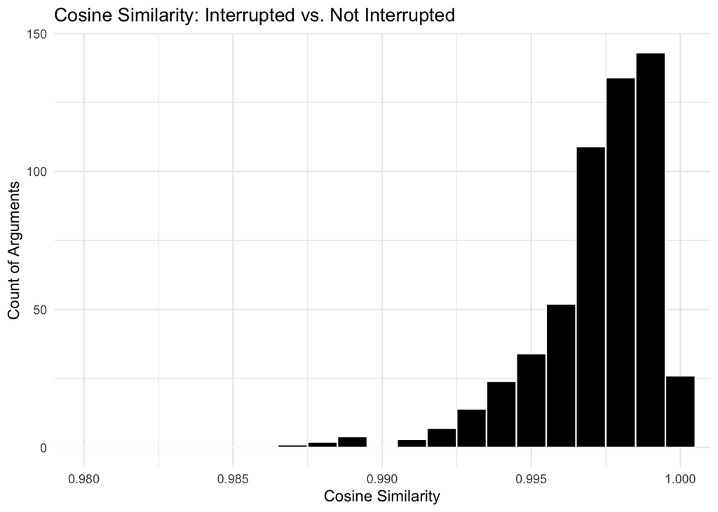

```r
library(ggplot2)

ggplot(advocate_embeddings_wide, aes(x = cosine_sim)) +
  geom_histogram(binwidth = 0.001, fill = "black", color = "white") +
  coord_cartesian(xlim = c(0.98, 1)) +  # zoom into dense range
  theme_minimal() +
  labs(
    title = "Cosine Similarity: Interrupted vs. Not Interrupted",
    x = "Cosine Similarity",
    y = "Count of Arguments"
  )
```

```r
colnames(df_unique)
```

```
##  [1] "case_id"
##  [2] "case_year"
##  [3] "justice_name"
##  [4] "advocate_name"
##  [5] "utt_id_first"
##  [6] "utt_id_last"
##  [7] "advocate_gender"
##  [8] "num_utts"
##  [9] "num_utts_adv"
## [10] "num_utts_justice"
## [11] "num_toks_total"
## [12] "num_toks_adv"
## [13] "num_toks_justice"
## [14] "advocate_ideology"
## [15] "justice_ideology"
## [16] "adv_experience_int"
## [17] "adv_experience_bin"
## [18] "female_issue"
## [19] "num_adv_utts_interrupted"
## [20] "num_justice_utts_interrupted"
## [21] "adv_interruption_rate"
## [22] "justice_interruption_rate"
## [23] "num_adv_disfl"
## [24] "num_justice_disfl"
## [25] "num_adv_toks_in_utts_interrupted"
## [26] "num_justice_toks_in_utts_interrupted"
## [27] "justice_gender"
## [28] "adv_ideology_gender"
## [29] "ideology_matches"
## [30] "chunk_text"
```

```r
df_with_text <- df_meta_embeds %>%
  left_join(df_unique %>%
              select(case_id, utt_id_first, chunk_text),
            by = c("case_id", "utt_id_first"))
```

```r
# Step 1: Find the lowest cosine similarity row
lowest <- advocate_embeddings_wide %>%
  filter(!is.na(cosine_sim)) %>%
  arrange(cosine_sim) %>%
  slice(1)

# Step 2: Pull both types of chunks for that advocate
df_with_text %>%
  filter(advocate_name == lowest$advocate_name) %>%
  select(interrupted, chunk_text)
```

```
## # A tibble: 4 × 2
##   interrupted     chunk_text
##   <chr>           <chr>
## 1 interrupted     "Your Honor, in -- in this case, in Valley, there is some cir…
## 2 interrupted     "What -- what you're doing -- what you're doing, Your Honor, …
## 3 interrupted     "Absolutely, Your Honor.\nIt fits under Penn Central.\nAnd in…
## 4 not_interrupted "Mr. Chief Justice, may I answer the question? He wanted one …
```

```r
lowest$cosine_sim
```

```
## [1] 0.8899362
```

#### 1. **Semantic content is largely preserved**

The near-perfect cosine similarity implies that **interrupted and uninterrupted statements from the same advocate have extremely similar semantic content**. That is, being interrupted **does not drastically shift the semantic vector** (meaning) of an advocate’s chunk — at least **as measured by average GloVe embeddings**.

#### 2. **Interruptions may affect delivery more than content**

This supports an interpretation that interruptions likely **disrupt flow or perception**, but not necessarily the semantic substance. This aligns with research noting that interruptions often reflect **power dynamics or interactional dominance**, rather than forcing an actual change in argumentative content.

## Q2: Gender effects on interruptions

Updated methodology:

We apply the NRC sentiment lexicon to assign emotion categories to each justice interruption. We then quantify the emotional content of interruptions directed at male versus female advocates, focusing on negative emotions (e.g., anger, disgust). Statistical comparisons test whether interruptions toward female advocates tend to be more emotionally negative, supporting our hypothesis of gendered treatment.

### Filter interrupted chunks only

These are where the **advocate was interrupted**, and we’re interested in what the **justice says**.

```r
interrupted_chunks <- df_cleaned %>%
  filter(num_adv_utts_interrupted > 0)
```

### Tokenize the chunk text (already cleaned)

```r
tokens_sentiment <- interrupted_chunks %>%
  select(case_id, utt_id_first, advocate_name, advocate_gender, chunk_text_clean) %>%
  unnest_tokens(word, chunk_text_clean)
```

#### Load the NRC Lexicon

```r
nrc <- get_sentiments("nrc")
```

#### Join Tokens with NRC

```r
tokens_labeled <- tokens_sentiment %>%
  inner_join(nrc, by = "word")
```

### Example: Negative emotions only

```r
negative_emotions <- c("anger", "fear", "disgust", "sadness")

emotion_summary_negative <- tokens_labeled %>%
  filter(sentiment %in% negative_emotions) %>%
  count(advocate_gender, sentiment) %>%
  group_by(advocate_gender) %>%
  mutate(prop = n / sum(n)) %>%
  ungroup()
```

#### Visualization

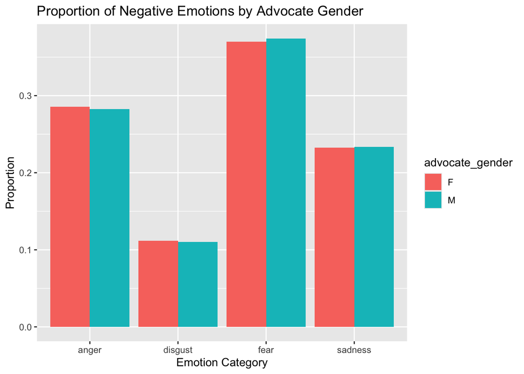

```r
ggplot(emotion_summary_negative, aes(x = sentiment, y = prop, fill = advocate_gender)) +
  geom_col(position = "dodge") +
  labs(title = "Proportion of Negative Emotions by Advocate Gender",
       y = "Proportion", x = "Emotion Category")
```

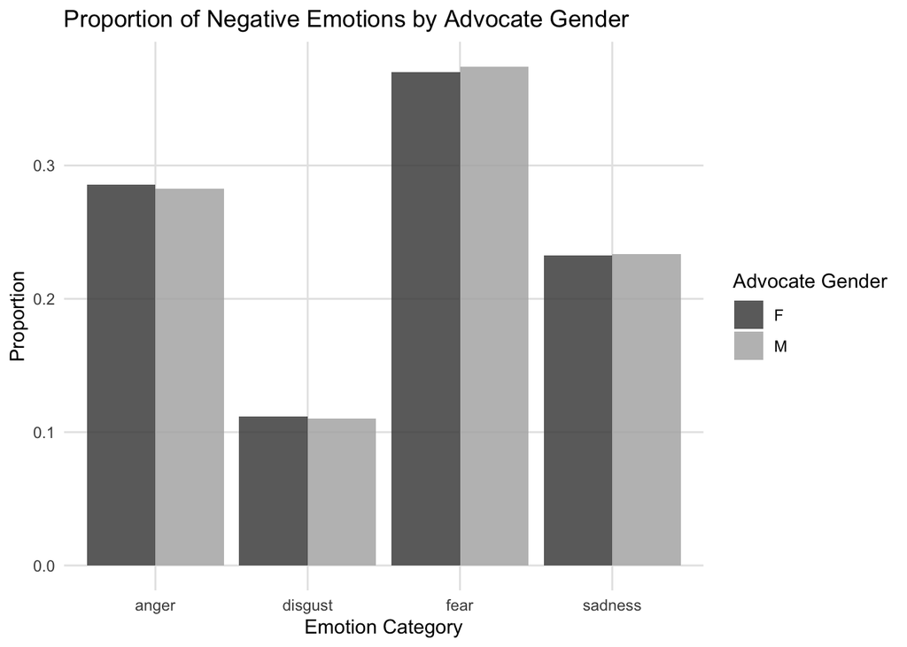

```r
# Plot for visualization

ggplot(emotion_summary_negative, aes(x = sentiment, y = prop, fill = advocate_gender)) +
  geom_col(position = "dodge", alpha = 0.85) +
  scale_fill_manual(
    values = c("F" = "gray30", "M" = "gray70")  # darker for F, lighter for M
  ) +
  labs(
    title = "Proportion of Negative Emotions by Advocate Gender",
    y = "Proportion",
    x = "Emotion Category",
    fill = "Advocate Gender"
  ) +
  theme_minimal() +
  theme(
    text = element_text(color = "black"),
    panel.grid.major = element_line(color = "gray90"),
    panel.grid.minor = element_blank()
  )
```

### Quantify emotion scores per chunk

```r
emotion_scores <- tokens_labeled %>%
  filter(sentiment %in% c("positive", "negative", "anger", "disgust", "fear", "sadness")) %>%
  group_by(case_id, utt_id_first, advocate_name, advocate_gender, sentiment) %>%
  summarise(word_count = n(), .groups = "drop") %>%
  pivot_wider(
    names_from = sentiment,
    values_from = word_count,
    values_fill = 0
  )
```

### Normalize emotion scores

```r
emotion_scores_normalized <- emotion_scores %>%
  mutate(
    total_emotion_words = positive + negative + anger + disgust + fear + sadness,
    neg_ratio = (negative + anger + disgust + fear + sadness) / total_emotion_words,
    pos_ratio = positive / total_emotion_words
  )
```

```r
emotion_gender_summary <- emotion_scores_normalized %>%
  group_by(advocate_gender) %>%
  summarise(
    avg_neg_ratio = mean(neg_ratio, na.rm = TRUE),
    avg_pos_ratio = mean(pos_ratio, na.rm = TRUE),
    n = n()
  )

emotion_gender_summary
```

```
## # A tibble: 2 × 4
##   advocate_gender avg_neg_ratio avg_pos_ratio     n
##   <chr>                   <dbl>         <dbl> <int>
## 1 F                       0.661         0.339  1362
## 2 M                       0.647         0.353  8935
```

```r
t.test(neg_ratio ~ advocate_gender, data = emotion_scores_normalized)
```

```
##
##  Welch Two Sample t-test
##
## data:  neg_ratio by advocate_gender
## t = 2.6623, df = 1729.7, p-value = 0.007834
## alternative hypothesis: true difference in means between group F and group M is not equal to 0
## 95 percent confidence interval:
##  0.003876661 0.025572405
## sample estimates:
## mean in group F mean in group M
##       0.6614017       0.6466771
```

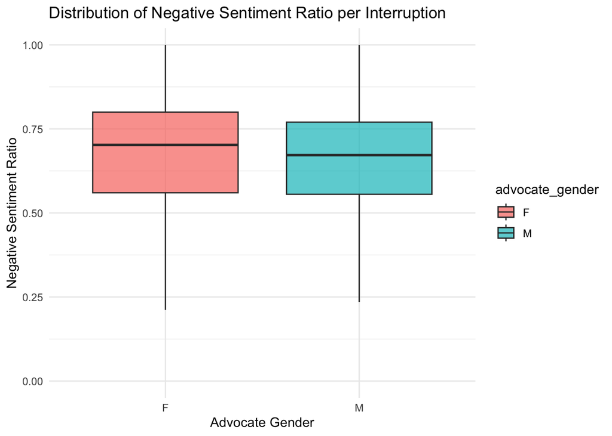

```r
df_with_ratios <- emotion_scores_normalized

ggplot(df_with_ratios, aes(x = advocate_gender, y = neg_ratio, fill = advocate_gender)) +
  geom_boxplot(alpha = 0.7, outlier.shape = NA) +
  labs(
    title = "Distribution of Negative Sentiment Ratio per Interruption",
    x = "Advocate Gender",
    y = "Negative Sentiment Ratio"
  ) +
  coord_cartesian(ylim = c(0, 1)) +
  theme_minimal()
```

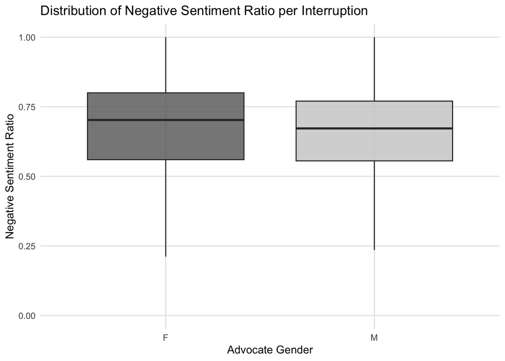

```r
# Plot for visualization
df_with_ratios <- emotion_scores_normalized

ggplot(df_with_ratios, aes(x = advocate_gender, y = neg_ratio, fill = advocate_gender)) +
  geom_boxplot(alpha = 0.8, outlier.shape = NA) +
  scale_fill_manual(
    values = c("F" = "gray40", "M" = "gray80")  # Adjust color tones for clarity
  ) +
  labs(
    title = "Distribution of Negative Sentiment Ratio per Interruption",
    x = "Advocate Gender",
    y = "Negative Sentiment Ratio"
  ) +
  coord_cartesian(ylim = c(0, 1)) +
  theme_minimal() +
  theme(
    legend.position = "none",
    panel.grid.major = element_line(color = "gray90"),
    panel.grid.minor = element_blank(),
    text = element_text(color = "black")
  )
```

We compared the proportion of negative sentiment in interruptions directed at male and female advocates using the NRC lexicon. After computing the negative sentiment ratio per interruption, we found that interruptions toward female advocates contained a significantly higher proportion of negative emotion words compared to those toward male advocates (Welch t-test, *p* = 0.0078).

This suggests a gender disparity in the tone of interruptions, with a greater frequency of dismissive or hostile language used when addressing female advocates.

### Linear Regression

```r
colnames(df_cleaned)
```

```
##  [1] "case_id"
##  [2] "case_year"
##  [3] "justice_name"
##  [4] "advocate_name"
##  [5] "utt_id_first"
##  [6] "utt_id_last"
##  [7] "advocate_gender"
##  [8] "num_utts"
##  [9] "num_utts_adv"
## [10] "num_utts_justice"
## [11] "num_toks_total"
## [12] "num_toks_adv"
## [13] "num_toks_justice"
## [14] "advocate_ideology"
## [15] "justice_ideology"
```

[output cut: 16 more lines]

```r
df_model <- emotion_scores_normalized %>%
  left_join(
    df_cleaned %>% select(case_id, utt_id_first, advocate_gender, adv_experience_int, case_year, female_issue, advocate_ideology, ideology_matches),
    by = c("case_id", "utt_id_first")
  )
```

```r
colnames(df_model)
```

```
##  [1] "case_id"             "utt_id_first"        "advocate_name"
##  [4] "advocate_gender.x"   "anger"               "disgust"
##  [7] "fear"                "negative"            "positive"
## [10] "sadness"             "total_emotion_words" "neg_ratio"
## [13] "pos_ratio"           "advocate_gender.y"   "adv_experience_int"
## [16] "case_year"           "female_issue"        "advocate_ideology"
## [19] "ideology_matches"
```

```r
df_model <- df_model %>%
  mutate(advocate_gender = coalesce(advocate_gender.x, advocate_gender.y)) %>%
  select(-advocate_gender.x, -advocate_gender.y)
```

```r
model <- lm(neg_ratio ~ advocate_gender + adv_experience_int + case_year + female_issue + advocate_ideology + ideology_matches, data = df_model)
summary(model)
```

```
##
## Call:
## lm(formula = neg_ratio ~ advocate_gender + adv_experience_int +
##     case_year + female_issue + advocate_ideology + ideology_matches,
##     data = df_model)
##
## Residuals:
##      Min       1Q   Median       3Q      Max
## -0.67073 -0.09258  0.02782  0.12432  0.39225
##
## Coefficients: (1 not defined because of singularities)
##                            Estimate Std. Error t value Pr(>|t|)
## (Intercept)              -1.4087998  1.2815897  -1.099   0.2717
## advocate_genderM         -0.0113790  0.0052349  -2.174   0.0298 *
## adv_experience_int       -0.0021587  0.0003996  -5.402 6.75e-08 ***
## case_year                 0.0010275  0.0006364   1.615   0.1064
## female_issue                     NA         NA      NA       NA
## advocate_ideologyliberal  0.0060803  0.0035424   1.716   0.0861 .
## ideology_matches          0.0017843  0.0035943   0.496   0.6196
## ---
## Signif. codes:  0 '***' 0.001 '**' 0.01 '*' 0.05 '.' 0.1 ' ' 1
##
## Residual standard error: 0.1785 on 10291 degrees of freedom
## Multiple R-squared:  0.004113,   Adjusted R-squared:  0.00363
## F-statistic: 8.501 on 5 and 10291 DF,  p-value: 4.831e-08
```

```r
# Create a document-term matrix (DTM)
lda_input <- df_cleaned %>%
  select(utt_id_first, chunk_text_clean) %>%
  unnest_tokens(word, chunk_text_clean) %>%
  anti_join(stop_words, by = "word") %>%
  count(utt_id_first, word) %>%
  cast_dtm(utt_id_first, word, n)
```

```r
lda_model <- LDA(lda_input, k = 6, control = list(seed = 42))
```

## LDA

```r
chunk_topics <- tidy(lda_model, matrix = "gamma")  # per-doc topic weights

# Merge topic probabilities back to original metadata
topic_df <- chunk_topics %>%
  pivot_wider(names_from = topic, values_from = gamma, names_prefix = "topic_") %>%
  left_join(df_cleaned, by = c("document" = "utt_id_first"))
```

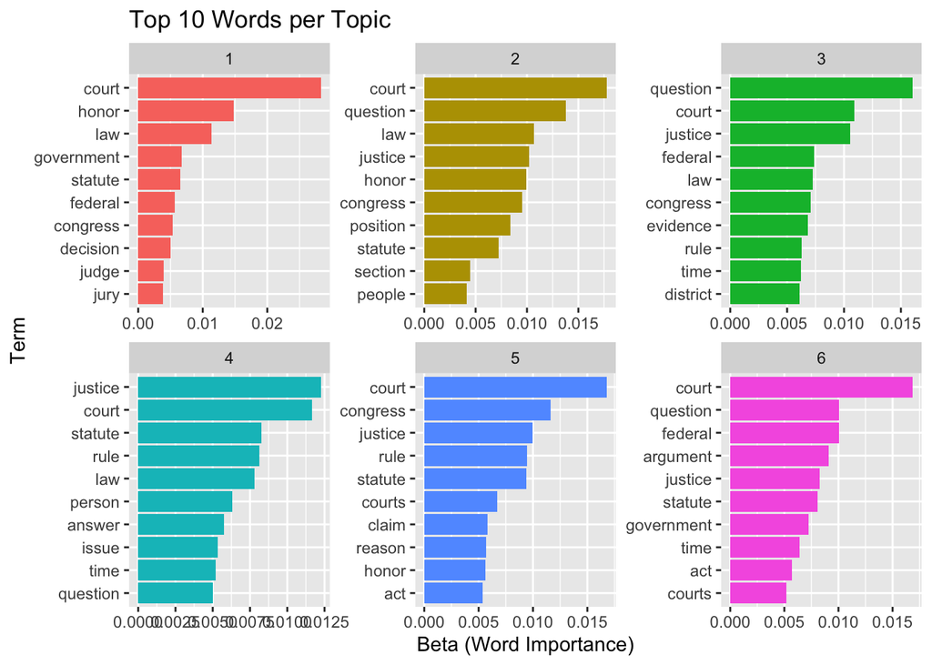

```r
# Extract top terms per topic
top_terms <- tidy(lda_model, matrix = "beta") %>%  # per-word topic probabilities
  group_by(topic) %>%
  top_n(10, beta) %>%  # top 10 words
  ungroup() %>%
  arrange(topic, -beta)


ggplot(top_terms, aes(x = reorder_within(term, beta, topic), y = beta, fill = factor(topic))) +
  geom_col(show.legend = FALSE) +
  facet_wrap(~ topic, scales = "free") +
  scale_x_reordered() +
  coord_flip() +
  labs(x = "Term", y = "Beta (Word Importance)", title = "Top 10 Words per Topic")
```

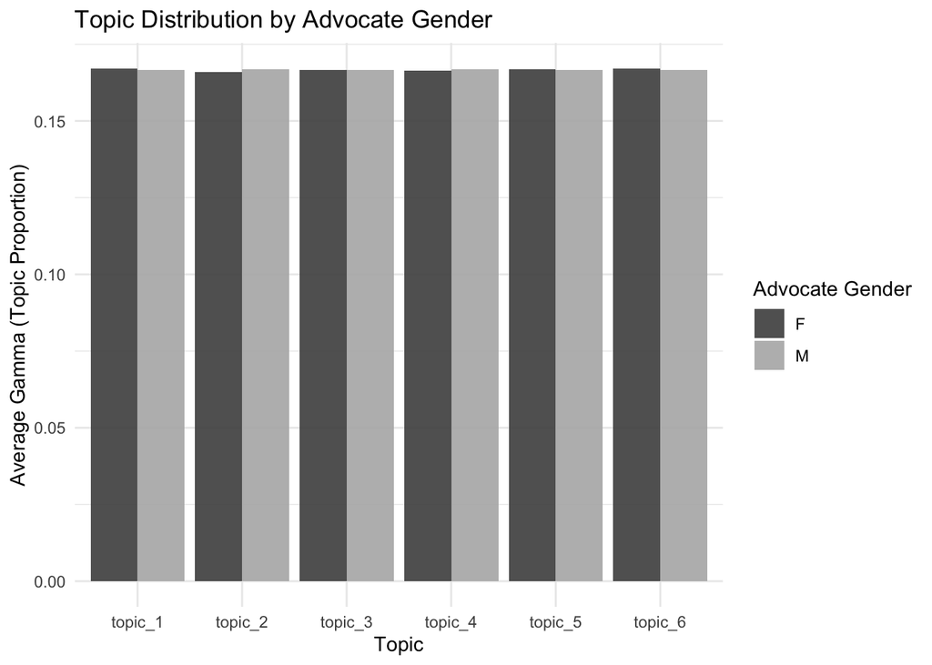

```r
gender_topics <- topic_df %>%
  filter(!is.na(advocate_gender)) %>%  # Remove rows with NA gender
  group_by(advocate_gender) %>%
  summarize(across(starts_with("topic_"), \(x) mean(x, na.rm = TRUE))) %>%
  pivot_longer(
    cols = starts_with("topic_"),
    names_to = "topic",
    values_to = "avg_gamma"
  )

# Plot
ggplot(gender_topics, aes(x = topic, y = avg_gamma, fill = advocate_gender)) +
  geom_col(position = "dodge", alpha = 0.9) +
  scale_fill_manual(values = c("F" = "gray30", "M" = "gray70")) +
  labs(
    x = "Topic",
    y = "Average Gamma (Topic Proportion)",
    title = "Topic Distribution by Advocate Gender",
    fill = "Advocate Gender"
  ) +
  theme_minimal()
```

```r
dtm <- df_cleaned %>%
  select(utt_id_first, chunk_text_clean) %>%
  unnest_tokens(word, chunk_text_clean) %>%
  anti_join(stop_words, by = "word") %>%
  count(utt_id_first, word) %>%
  cast_dtm(utt_id_first, word, n)


lda_model_10 <- LDA(dtm, k = 10, control = list(seed = 123))

# Get top terms per topic
top_terms <- tidy(lda_model_10, matrix = "beta") %>%
  group_by(topic) %>%
  slice_max(beta, n = 10) %>%  # top 10 words
  ungroup()

# View terms per topic
top_terms %>%
  arrange(topic, -beta) %>%
  print(n = 60)  # print more rows for inspection
```

```
## # A tibble: 100 × 3
##    topic term          beta
##    <int> <chr>        <dbl>
##  1     1 honor      0.0126
##  2     1 question   0.0120
##  3     1 justice    0.0112
##  4     1 congress   0.0110
##  5     1 act        0.0103
##  6     1 statute    0.00906
##  7     1 court      0.00848
##  8     1 people     0.00702
##  9     1 law        0.00628
## 10     1 correct    0.00528
## 11     2 question   0.0165
## 12     2 law        0.0164
```

[output cut: 49 more lines]

```r
# Prepare topic dataframe and join with emotion scores
topic_df <- chunk_topics %>%
  rename(utt_id_first = document) %>%  # Align column name for join
  pivot_wider(
    names_from = topic,
    values_from = gamma,
    names_prefix = "topic_"
  ) %>%
  left_join(
    emotion_scores_normalized %>%
      select(utt_id_first, neg_ratio, advocate_gender),
    by = "utt_id_first"
  )

# Fit linear model predicting negative sentiment ratio
model_topic <- lm(
  neg_ratio ~ advocate_gender + topic_1 + topic_2 + topic_3 + topic_4 + topic_5 + topic_6,
  data = topic_df
)

# Output model summary
summary(model_topic)
```

```
##
## Call:
## lm(formula = neg_ratio ~ advocate_gender + topic_1 + topic_2 +
##     topic_3 + topic_4 + topic_5 + topic_6, data = topic_df)
##
## Residuals:
##      Min       1Q   Median       3Q      Max
## -0.67530 -0.09066  0.02870  0.12255  0.36761
##
## Coefficients: (1 not defined because of singularities)
##                   Estimate Std. Error t value Pr(>|t|)
## (Intercept)       0.997601   0.144725   6.893 5.78e-12 ***
## advocate_genderM -0.012591   0.005136  -2.452  0.01424 *
## topic_1           1.056742   0.234985   4.497 6.97e-06 ***
## topic_2          -0.938528   0.211317  -4.441 9.03e-06 ***
## topic_3          -1.151661   0.224889  -5.121 3.09e-07 ***
## topic_4          -1.704933   0.217994  -7.821 5.75e-15 ***
## topic_5           0.710656   0.227358   3.126  0.00178 **
## topic_6                 NA         NA      NA       NA
## ---
## Signif. codes:  0 '***' 0.001 '**' 0.01 '*' 0.05 '.' 0.1 ' ' 1
##
## Residual standard error: 0.1765 on 10290 degrees of freedom
##   (2366 observations deleted due to missingness)
## Multiple R-squared:  0.02644,    Adjusted R-squared:  0.02587
## F-statistic: 46.57 on 6 and 10290 DF,  p-value: < 2.2e-16
```